# Untitled

## Introduction

In social science (and educational) research, we often wish to understand how robust inferences about effects are to unobserved (or controlled for) covariates, possible problems with measurement, and other sources of bias. The goal of `konfound` is to carry out sensitivity analysis to help analysts to quantify how robust inferences are to potential sources of bias. This package provides functions based on developments in sensitivity analysis by Frank and colleagues, which previously have been implemented in `Stata` and through an Excel spreadsheet, in `R` through the `konfound` package.

# Background on sensitivity analysis

Often times, inferences about effects are critiqued because of *biases*, or factors that contribute to an estimated effect being different from its ground truth value. These biases come from many sources, such as not including possibly important control variables or covariates and sample (i.e., selection bias) and measurement-related (i.e., not measuring the complete nature of a psychological construct) biases.

The first approach, termed the replacement of cases approach, uses Rubin’s causal model to interpret how much bias there must be to invalidate an inference in terms of replacing observed cases with counterfactual cases. The second quantifies the robustness of causal inferences in terms of correlations associated with unobserved variables in a regression framework.

## Correlation-based approach to sensitivty analysis

In many non-experimental studies, there is a concern that a variable not considered or included in the analysis is related to both the outcome and predictor of interest. In these cases, not considering the omitted, confounding variable may mean that estimates are biased–they are over-confident. In this approach to sensitivity analysis, the strength of the correlation between a hypothetical omitted variable and the outcome and predictor of interest is quantified.

# Tutorial

In this section, we provide a tutorial of the use of **konfound** to carry out sensitivity analysis through both the replacement of cases and correlation-based approach.

First, you can install `konfound` with the following:

```r
install.packages("konfound")
```

You can then load konfound with the `library()` function:

```r
library(konfound)
```

## Example 1: Use of pkonfound() for values from an already-conducted analysis

`pkonfound()` is used when we have values from an already-conducted analysis (like a regression analysis), such as one in an already-published study or from an analysis carried out using other software.

In the case of a regression analysis, values from the analysis would simply be used as the inputs to the `pkonfound()` function. For example, in the use below, we simply enter the values for the estimated effect (an unstandardardized beta coefficient) (`2`), its standard error (`.4`), the sample size (`100`), and the number of covariates (`3`):

```r
pkonfound(2, 0.4, 100, 3)
```

```
#> Percent Bias Necessary to Invalidate the Inference:
#> To invalidate an inference, 60.3% of the estimate would have to be due to bias. This is based on a threshold of 0.794 for statistical significance (alpha = 0.05).
#> To invalidate an inference, 60 observations would have to be replaced with cases for which the effect is 0.
#>
#> Impact Threshold for a Confounding Variable:
#> An omitted variable would have to be correlated at 0.568 with the outcome and at 0.568 with the predictor of interest (conditioning on observed covariates) to invalidate an inference based on a threshold of 0.201 for statistical significance (alpha = 0.05).
#> Correspondingly the impact of an omitted variable (as defined in Frank 2000) must be 0.568 X 0.568 = 0.323 to invalidate an inference.
#> For other forms of output, change `to_return` to table, raw_output, thres_plot, or corr_plot.
#> For models fit in R, consider use of konfound().
```

For this set of values, around 60% would need to be false due to a source of bias for the inference to be invalidated (based on statistical significance and a p-value (or alpha) of .05), possible a very robust effect. An omitted, confounding variable (sometimes referred to as a covariate) would need to have an impact (defined as the product of the confounding variable’s correlation with both the predictor of interest and the outcome) of 0.323, presenting a different interpretation of how robust this (hypothetical) effect is to a variable which is important but not included in the analysis.

Here is another example, but one in which the unstandardized beta coefficient is smaller than its standard error:

```r
pkonfound(0.4, 2, 100, 3)
```

```
#> Percent Bias Necessary to Invalidate the Inference:
#> To sustain an inference, 89.924% of the estimate would have to be due to bias. This is based on a threshold of 3.97 for statistical significance (alpha = 0.05).
#> To sustain an inference, 90 of the cases with 0 effect would have to be replaced with cases at the threshold of inference.
#>
#> Impact Threshold for a Confounding Variable:
#> An omitted variable would have to be correlated at 0.387 with the outcome and at 0.387 with the predictor of interest (conditioning on observed covariates) to sustain an inference based on a threshold of 3.97 for statistical significance (alpha = 0.05).
#> Correspondingly the impact of an omitted variable (as defined in Frank 2000) must be 0.387 X 0.387 = 0.15 to sustain an inference.
#> For other forms of output, change `to_return` to table, raw_output, thres_plot, or corr_plot.
#> For models fit in R, consider use of konfound().
```

Note that this use of `pkonfound()` is equivalent to naming the arguments, i.e. for a different set of values:

```r
pkonfound(est_eff = -2.2, std_err = 0.65, n_obs = 200, n_covariates = 3)
```

```
#> Percent Bias Necessary to Invalidate the Inference:
#> To invalidate an inference, 41.732% of the estimate would have to be due to bias. This is based on a threshold of -1.282 for statistical significance (alpha = 0.05).
#> To invalidate an inference, 83 observations would have to be replaced with cases for which the effect is 0.
#>
#> Impact Threshold for a Confounding Variable:
#> An omitted variable would have to be correlated at 0.334 with the outcome and at 0.334 with the predictor of interest (conditioning on observed covariates) to invalidate an inference based on a threshold of -0.14 for statistical significance (alpha = 0.05).
#> Correspondingly the impact of an omitted variable (as defined in Frank 2000) must be 0.334 X 0.334 = 0.112 to invalidate an inference.
#> For other forms of output, change `to_return` to table, raw_output, thres_plot, or corr_plot.
#> For models fit in R, consider use of konfound().
```

We notice that the output includes a message that says we can view other forms of output by changing the `to_return` argument. Here are the two plots - for the bias necessary to alter an inference (`thresh_plot`) and for the robustness of an inference in terms of the impact of a confounding variable (`corr_plot`) that can be returned:

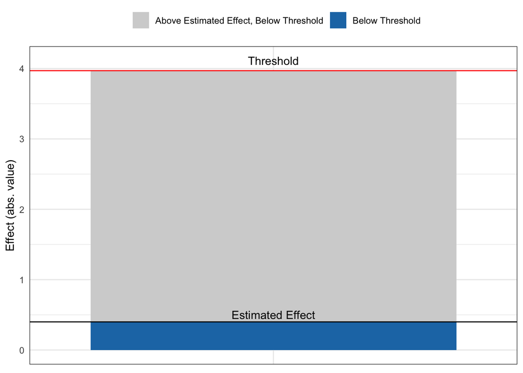

```r
pkonfound(0.4, 2, 100, 3, to_return = "thresh_plot")
```

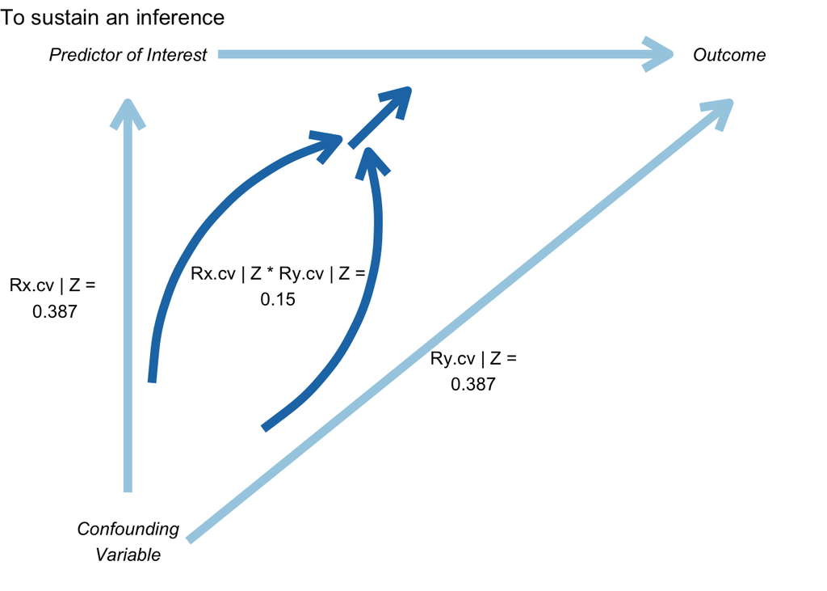

```r
pkonfound(0.4, 2, 100, 3, to_return = "corr_plot")
```

You can also specify multiple forms of output at once.

```r
model_output <- pkonfound(2, 0.4, 200, 3, to_return = c("raw_output", "thresh_plot",
    "corr_plot"))
```

```
#> Percent Bias Necessary to Invalidate the Inference:
#> To invalidate an inference, 60.557% of the estimate would have to be due to bias. This is based on a threshold of 0.789 for statistical significance (alpha = 0.05).
#> To invalidate an inference, 121 observations would have to be replaced with cases for which the effect is 0.
#>
#> Impact Threshold for a Confounding Variable:
#> An omitted variable would have to be correlated at 0.479 with the outcome and at 0.479 with the predictor of interest (conditioning on observed covariates) to invalidate an inference based on a threshold of 0.14 for statistical significance (alpha = 0.05).
#> Correspondingly the impact of an omitted variable (as defined in Frank 2000) must be 0.479 X 0.479 = 0.229 to invalidate an inference.
#> Print output created by default. Created 3 other forms of output. Use list indexing or run summary() on the output to see how to access.
```

```r
summary(model_output)
```

```
#> Created 3 forms of output. To access type:
#>
#> model_output$raw_output
#> model_output$thresh_plot
#> model_output$corr_plot
```

When we type the name of the object, we see that we created three types of output that we can access as follows:

```r
model_output$raw_output
```

```
#> # A tibble: 1 x 8
#>   action inference percent_bias_to… replace_null_ca… unstd_beta
#>   <chr>  <chr>                <dbl>            <dbl>      <dbl>
#> 1 to_in… reject_n…             60.6              121          2
#> # … with 3 more variables: beta_threshhold <dbl>,
#> #   omitted_variable_corr <dbl>, itcv <dbl>
```

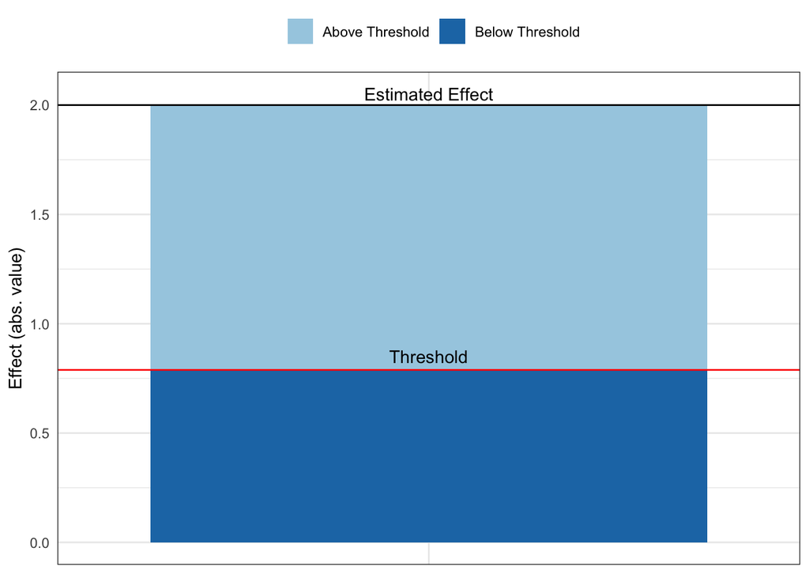

```r
model_output$thresh_plot
```

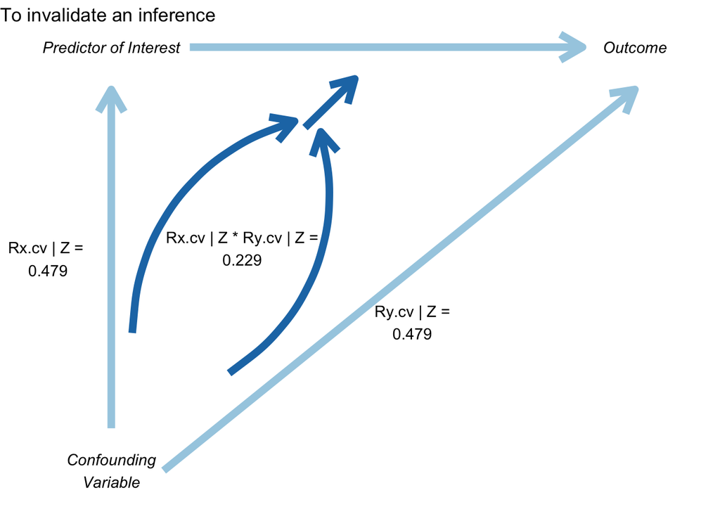

```r
model_output$corr_plot
```

Finally, you can return the raw output, for use in other analyses.

```r
pkonfound(0.4, 2, 100, 3, to_return = "raw_output")
```

```
#> # A tibble: 1 x 8
#>   action inference percent_bias_to… replace_null_ca… unstd_beta
#>   <chr>  <chr>                <dbl>            <dbl>      <dbl>
#> 1 to_su… fail_to_…             89.9               90        0.4
#> # … with 3 more variables: beta_threshhold <dbl>,
#> #   omitted_variable_corr <dbl>, itcv <dbl>
```

## Use of konfound() for models fit in R

Where `pkonfound()` can be used with values from already-conducted analyses, `konfound()` can be used with models (`lm()`, `glm()`, and `lme4::lmer()`) fit in R.

### Example 2A: For linear models fit with lm()

```r
m1 <- lm(mpg ~ wt + hp + qsec, data = mtcars)
m1
```

```
#>
#> Call:
#> lm(formula = mpg ~ wt + hp + qsec, data = mtcars)
#>
#> Coefficients:
#> (Intercept)           wt           hp         qsec
#>    27.61053     -4.35880     -0.01782      0.51083
```

```r
konfound(m1, hp)
```

```
#> Note that this output is calculated based on the correlation-based approach used in mkonfound()
#> Percent Bias Necessary to Invalidate the Inference:
#> To sustain an inference, 41.327% of the estimate would have to be due to bias. This is based on a threshold of -0.031 for statistical significance (alpha = 0.05).
#> To sustain an inference, 13 of the cases with 0 effect would have to be replaced with cases at the threshold of inference.
#>
#> Impact Threshold for a Confounding Variable:
#> An omitted variable would have to be correlated at 0.322 with the outcome and at 0.322 with the predictor of interest (conditioning on observed covariates) to sustain an inference based on a threshold of -0.031 for statistical significance (alpha = 0.05).
#> Correspondingly the impact of an omitted variable (as defined in Frank 2000) must be 0.322 X 0.322 = 0.104 to sustain an inference.
#> For more detailed output, consider setting `to_return` to table
#> To consider other predictors of interest, consider setting `test_all` to TRUE.
```

Like with `pkonfound()`, we can also output multiple forms of output at once with `konfound()`:

```r
konfound_output <- konfound(m1, hp, to_return = c("raw_output", "thresh_plot",
    "corr_plot"))
```

```
#> Note that this output is calculated based on the correlation-based approach used in mkonfound()
#> Percent Bias Necessary to Invalidate the Inference:
#> To sustain an inference, 41.327% of the estimate would have to be due to bias. This is based on a threshold of -0.031 for statistical significance (alpha = 0.05).
#> To sustain an inference, 13 of the cases with 0 effect would have to be replaced with cases at the threshold of inference.
#>
#> Impact Threshold for a Confounding Variable:
#> An omitted variable would have to be correlated at 0.322 with the outcome and at 0.322 with the predictor of interest (conditioning on observed covariates) to sustain an inference based on a threshold of -0.031 for statistical significance (alpha = 0.05).
#> Correspondingly the impact of an omitted variable (as defined in Frank 2000) must be 0.322 X 0.322 = 0.104 to sustain an inference.
#> Print output created by default. Created 3 other forms of output. Use list indexing or run summary() on the output to see how to access.
```

```r
summary(konfound_output)
```

```
#> Created 3 forms of output. To access type:
#>
#> konfound_output$raw_output
#> konfound_output$thresh_plot
#> konfound_output$corr_plot
```

Again, we can type each of those, i.e.:

```r
konfound_output$raw_output
```

```
#> # A tibble: 1 x 8
#>   action inference percent_bias_to… replace_null_ca… unstd_beta
#>   <chr>  <chr>                <dbl>            <dbl>      <dbl>
#> 1 to_su… fail_to_…             41.3               13     -0.018
#> # … with 3 more variables: beta_threshhold <dbl>,
#> #   omitted_variable_corr <dbl>, itcv <dbl>
```

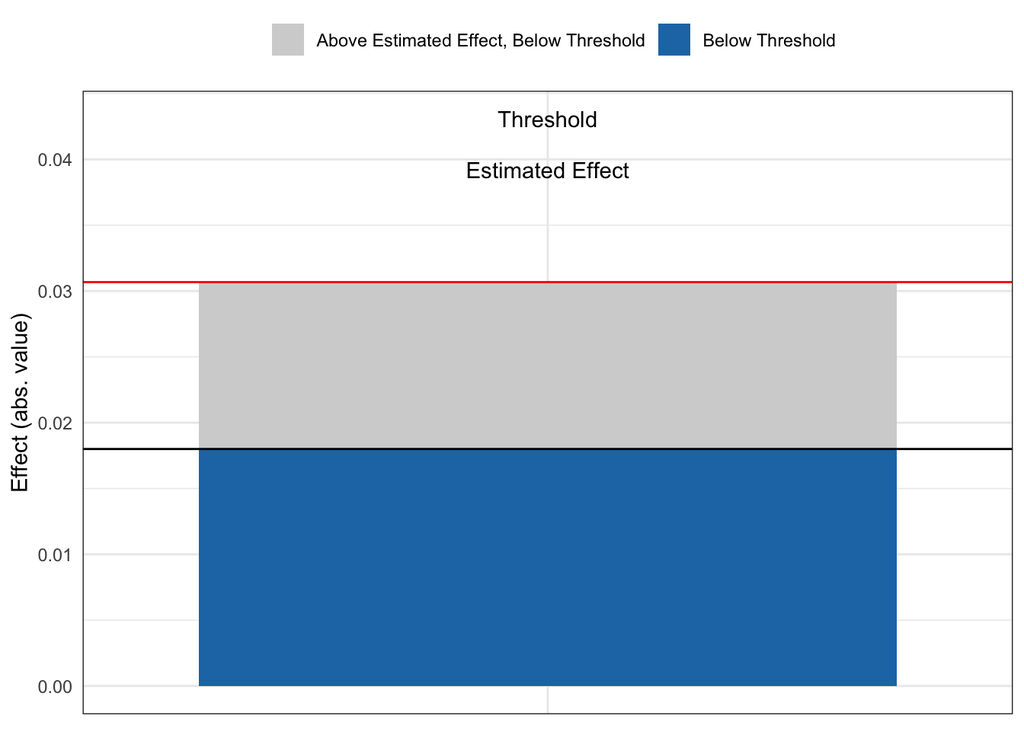

```r
konfound_output$thresh_plot
```

We can also test all of the variables as predictors of interest:

```r
konfound(m1, wt, test_all = TRUE)
```

```
#> # A tibble: 3 x 8
#>   var_name     t    df action   inference   pct_bias_to_chang…   itcv r_con
#>   <chr>    <dbl> <dbl> <chr>    <chr>                    <dbl>  <dbl> <dbl>
#> 1 wt       -5.79    29 to_inva… reject_null               51.5  0.585 0.765
#> 2 hp       -1.2     29 to_sust… fail_to_re…               38.7 -0.102 0.319
#> 3 qsec      1.16    29 to_sust… fail_to_re…               40.5 -0.106 0.326
```

Whereas this cannot be carried out with `pkonfound()`, with `konfound()` you can also return a table with some key output from the correlation-based approach.

```r
konfound(m1, wt, to_return = "table")
```

```
#> Note that this output is calculated based on the correlation-based approach used in mkonfound()
#> Dependent variable is mpg
#> Warning: Unknown or uninitialised column: 'itcv'.
#> Warning: Unknown or uninitialised column: 'impact'.
#> # A tibble: 4 x 7
#>   term        estimate std.error statistic p.value   itcv impact
#>   <chr>          <dbl>     <dbl>     <dbl>   <dbl>  <dbl>  <dbl>
#> 1 (Intercept)   27.6       8.42       3.28   0.003 NA     NA
#> 2 wt            -4.36      0.753     -5.79   0      0.243 NA
#> 3 hp            -0.018     0.015     -1.19   0.244 NA      0.511
#> 4 qsec           0.511     0.439      1.16   0.255 NA      0.073
```

If the impact threshhold is greater than the impacts of the `Z`s (the other covariates) then an omitted variable would have to have a greater impact than any of the observed covariates to change the inference. Note that in fields in which there is a lot known about covariates given the outcome of interest, then the omitted ones are likely less important than those that are known an included (i.e., we have a good sense of the factors that matter in terms of educational achievement).

### Example 2B: For generalized linear models fit with glm()

Effects for these models are interpreted on the basis of average partial (or marginal) effects (calculated using the `margins` package).

```r
# if forcats is not installed, this install it first using
# install.packages('forcats') for this to run
if (requireNamespace("forcats")) {
    d <- forcats::gss_cat

    d$married <- ifelse(d$marital == "Married", 1, 0)

    m2 <- glm(married ~ age, data = d, family = binomial(link = "logit"))
    konfound(m2, age)
}
```

```
#> Percent Bias Necessary to Invalidate the Inference:
#> To sustain an inference, 80.978% of the estimate would have to be due to bias. This is based on a threshold of 0.013 for statistical significance (alpha = 0.05).
#> To sustain an inference, 17334 of the cases with 0 effect would have to be replaced with cases at the threshold of inference.
#>
#> Impact Threshold for a Confounding Variable:
#> An omitted variable would have to be correlated at 5.535 with the outcome and at 5.535 with the predictor of interest (conditioning on observed covariates) to invalidate an inference based on a threshold of 1.003 for statistical significance (alpha = 0.05).
#> Correspondingly the impact of an omitted variable (as defined in Frank 2000) must be 5.535 X 5.535 = 30.636 to invalidate an inference.
#> NULL
```

As with models fit with `lm()` (and use of `pkonfound()`), multiple forms of output can be specified with the `to_return` argument to `konfound()`, i.e. `konfound(m2, age, to_return = c("raw_output", "corr_plot", "thresh_plot"))`.

### Example 2C: For mixed effects (or multi-level) models fit with the lmer() function from the lme4 package

`konfound` also works with models fit with the `lmer()` function from the package `lme4`, for mixed-effects or multi-level models. One challenge with carrying out sensitivity analysis for fixed effects in mixed effects models is calculating the correct denominator degrees of freedom for the t-test associated with the coefficients. This is not unique to sensitivity analysis, as, for example, `lmer()` does not report degrees of freedom (or p-values) for fixed effects predictors (see this information in the `lme4` FAQ [here](http://bbolker.github.io/mixedmodels-misc/glmmFAQ.html#why-doesnt-lme4-display-denominator-degrees-of-freedomp-values-what-other-options-do-i-have)). While it may be possible to determine the correct degrees of freedom for some models (i.e., models with relatively simple random effects structures), it is difficult to generalize this approach, and so in this package the Kenward-Roger approximation for the denominator degrees of freedom as implemented in the `pbkrtest` package (described in [Halekoh and Højsgaard, 2014](https://www.jstatsoft.org/htaccess.php?volume=59&type=i&issue=09&paper=true)).

Here is an example of the use of `konfound()` with a model fit with `lmer()`:

```r
if (requireNamespace("lme4")) {
    library(lme4)
    m3 <- fm1 <- lmer(Reaction ~ Days + (1 | Subject), sleepstudy)
    konfound(m3, Days)
}
```

[output not shown]

### Example 2D: Use of mkonfound() for meta-analyses that include sensitivity analysis

We can also use `konfound` to carry out sensitivity analysis as part of meta-analyses. For example, here, `d` represents output from a number (30 in this case) of past studies, read in a CSV file from a website:

```r
d <- read.csv("https://msu.edu/~kenfrank/example%20dataset%20for%20mkonfound.csv")
head(d)
```

```
#>           t  df
#> 1  7.076763 178
#> 2  4.127893 193
#> 3  1.893137  47
#> 4 -4.166395 138
#> 5 -1.187599  97
#> 6  3.585478  87
```

```r
mkonfound(d, t, df)
```

```
#> # A tibble: 30 x 7
#>         t    df action     inference     pct_bias_to_change_i…   itcv r_con
#>     <dbl> <int> <chr>      <chr>                         <dbl>  <dbl> <dbl>
#>  1  7.08    178 to_invali… reject_null                   68.8   0.378 0.614
#>  2  4.13    193 to_invali… reject_null                   50.6   0.168 0.41
#>  3  1.89     47 to_sustain fail_to_reje…                  5.47 -0.012 0.11
#>  4 -4.17    138 to_invali… reject_null                   50.3   0.202 0.449
#>  5 -1.19     97 to_sustain fail_to_reje…                 39.4  -0.065 0.255
#>  6  3.59     87 to_invali… reject_null                   41.9   0.19  0.436
#>  7  0.282   117 to_sustain fail_to_reje…                 85.5  -0.131 0.361
#>  8  2.55     75 to_invali… reject_null                   20.6   0.075 0.274
#>  9 -4.44    137 to_invali… reject_null                   53.0   0.225 0.475
#> 10 -2.05    195 to_invali… reject_null                    3.51  0.006 0.077
#> # … with 20 more rows
```

We can also return a plot summarizing the percent bias needed to sustan or invalidate an inference across all of the past studies:

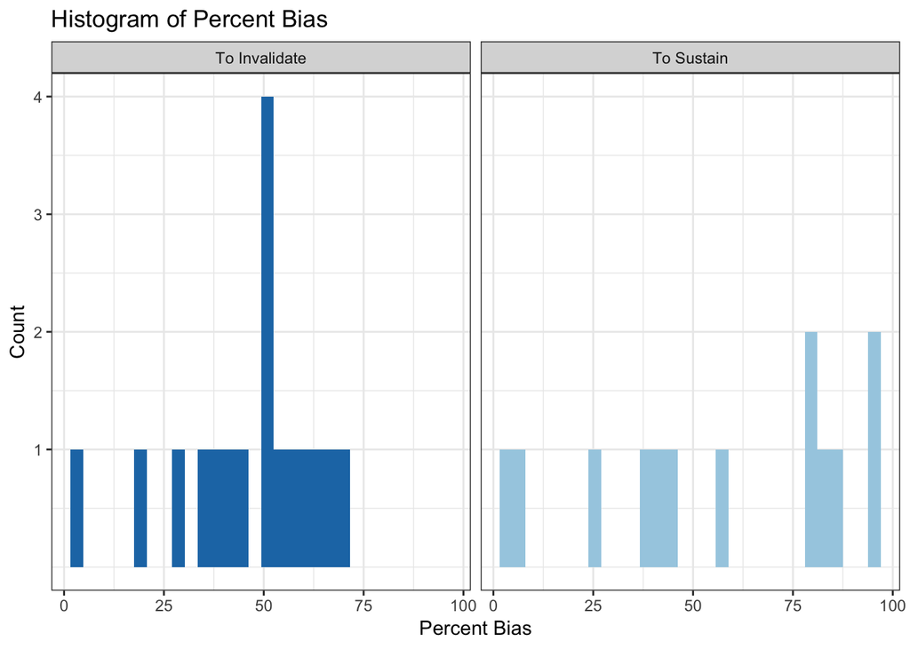

```r
mkonfound(d, t, df, return_plot = T)
```